# Binary Logistic Regression Assignment

- Show All Code
- Hide All Code
- View Source

Titanic Data Analysis using Binary Logistic Regression

Author

Caotao Qiu (Genesis)

## Purpose

In this assignment, I will apply binary logistic regression analysis to investigate the factors associated with surviving the Titanic crash using **titanic::titanic_train**.

My objectives are to:

- Specify and estimate several plausible competing binary logistic regression models using `glmmTMB`.
- Compare nested models using likelihood-ratio tests (χ²).
- Evaluate overall model fit using AIC and BIC.
- Examine model diagnostics and assess assumptions relevant to binary logistic regression.
- Select and interpret a preferred model, including transforming log-odds coefficients into odds ratios.
- Report results reproducibly using tables, figures, and Quarto.

## 1. Load packages and prepare the data

```r
library(glmmTMB)
library(dplyr)
library(tidyr)
library(ggplot2)
library(broom.mixed)
library(performance)
library(gt)
library(readr)
library(DHARMa)
library(ggeffects)
library(titanic)

titanic <- titanic_train

# Keep the same complete-case sample for every model
titanic <- titanic |>
  select(Survived, Sex, Age, Pclass) |>
  drop_na() |>
  mutate(
    Sex.Binary = case_when(
      Sex == "male" ~ 0,
      Sex == "female" ~ 1)) |>
  mutate(
    Survived.Char = case_when(
      Survived == 0 ~ "Died",
      Survived == 1 ~ "Survived")) |>
  mutate(
    Pclass.Char = case_when(
      Pclass == "1" ~ "First Class",
      Pclass == "2" ~ "Second Class",
      Pclass == "3" ~ "Third Class")) |>
  mutate(Pclass = factor(Pclass, levels = c(1, 2, 3))) |>
  select(Survived, Survived.Char, Sex, Sex.Binary, Pclass, Pclass.Char, Age)

n <- nrow(titanic)
```

I will only complete-case data from this dataset, which include **n = 714 passengers**. The binary outcome variable is `Survived`: whether the passenger survived (`1`) or died (`0`). I also include three predictor variables (`Sex`, `Pclass`, and `Age`) that would associate with the chance of survival during the Titanic disaster.

| Variable | Description | Role |
| --- | --- | --- |
| Survived | Whether a passenger survived or died in the crash | Outcome |
| Sex | Sex reported on legal documents | Predictor |
| Age | Self-reported age in years | Predictor |
| Pclass | What type of ticket was purchased; my proxy for socioeconomic status (SES) | Predictor |

## 2. Explore the data

Below are the descriptive statistics for the continuous variable of `Age` and the cell counts for each categorical variable (`Survived`, `Sex`, and `Pclass`).

### 2.1 Descriptive statistics for continuous variables

```r
descriptives <- titanic |>
  summarise(
    across(
      c(Age),
      list(mean = mean, sd = sd, min = min, max = max)
    )
  ) |>
  pivot_longer(
    everything(),
    names_to = c("variable", ".value"),
    names_sep = "_"
  )

descriptives |>
  gt() |>
  cols_label(
    variable = "Variable",
    mean = "Mean",
    sd = "SD",
    min = "Minimum",
    max = "Maximum"
  ) |>
  fmt_number(columns = where(is.numeric), decimals = 2)
```

| Variable | Mean | SD | Minimum | Maximum |
| --- | --- | --- | --- | --- |
| Age | 29.70 | 14.53 | 0.42 | 80.00 |

### 2.2 Cell counts for categorical variables

#### Survival status

```r
titanic |>
  count(Survived.Char) |>
  gt() |>
  cols_label(
    Survived.Char = "Survival Status",
    n = "Count"
  )
```

| Survival Status | Count |
| --- | --- |
| Died | 424 |
| Survived | 290 |

#### Passenger sex

```r
titanic |>
  count(Sex) |>
  gt() |>
  cols_label(
    Sex = "Sex",
    n = "Count"
  )
```

| Sex | Count |
| --- | --- |
| female | 261 |
| male | 453 |

#### Ticket class

```r
titanic |>
  count(Pclass.Char) |>
  gt() |>
  cols_label(
    Pclass.Char = "Ticket Class",
    n = "Count"
  )
```

| Ticket Class | Count |
| --- | --- |
| First Class | 186 |
| Second Class | 173 |
| Third Class | 355 |

### 2.3 Summary of exploratory patterns

Across the 714 passengers with complete data, the average age was approximately 29.7 years (SD = 14.53 years), ranging from infants (0.42 years) to elderly (80 years). The cell counts across the categorical variables are not evenly distributed, which align with historical contexts and disaster outcomes. Specifically, male passengers outnumbered females (453 males vs. 261 females), , while Third-Class passengers made up nearly half of the sample (355 in Third-Class compared to 186 in First-Class and 173 in Second-Class), and most importantly, a majority of passengers died (424 died vs. 290 survived).

Despite these imbalances, every category contains well over the minimum number of observations needed to reliably estimate binary logistic regression parameters.

## 3. Specify and estimate competing models

### 3.1. Research question and substantive predictions

**Research Question:** How are passenger `Sex`, `Pclass`, and `Age` associated with whether a passenger `Survived` the sinking of the Titanic?

Based on historical context from 1912 and maritime evacuation norms, I expect all three predictors to be meaningfully associated with survival:

- **Sex:** Under the “women and children first” doctrine enforced during the 1912 crash, female passengers were given priority access to lifeboats. Therefore, I predict that male passengers had substantially lower odds of surviving than female passengers.
- **Pclass:** Ticket class serves as a proxy for SES. First-Class passengers had cabins located on upper decks closer to the lifeboats and received preferential treatment during evacuation, whereas Third-Class passengers lived on lower decks experienced flooding first and needed more time/effort to reach the lifeboats. I predict that Second and Third-Class passengers had lower odds of survival relative to First-Class passengers.
- **Age:** Because young children were prioritized alongside women when accessing lifeboats and older passengers may have faced greater physical barriers reaching the upper decks in difficult conditions, I predict that older age is associated with lower odds of surviving, and lower age is associated with higher odds of surviving, holding sex and ticket class constant.

These are predictions about statistical associations in observational data, not experimental causal effects.

### 3.2. Specify four nested models

I will fit an intercept-only baseline model and three increasingly complex substantive models:

| Model | Formula | Purpose / Research rationale |
| --- | --- | --- |
| mod0: Null | `Survived ~ 1` | Establish a baseline |
| mod1: Sex | `Survived ~ Sex` | Evaluate the association of sex with survival |
| mod2: Sex + Pclass | `Survived ~ Sex + Pclass` | Evaluate the additional contribution of ticket class |
| mod3: Sex + Pclass + Age | `Survived ~ Sex + Pclass + Age` | Evaluate the additional contribution of passenger age |

The models are **nested**: each successive model contains all predictors from the preceding model, plus one additional predictor.

```r
mod0 <- glmmTMB(
  Survived ~ 1,
  data = titanic,
  family = binomial(link = "logit")
)

mod1 <- glmmTMB(
  Survived ~ Sex,
  data = titanic,
  family = binomial(link = "logit")
)

mod2 <- glmmTMB(
  Survived ~ Sex + Pclass,
  data = titanic,
  family = binomial(link = "logit")
)

mod3 <- glmmTMB(
  Survived ~ Sex + Pclass + Age,
  data = titanic,
  family = binomial(link = "logit")
)
```

```r
summary(mod0)
summary(mod1)
summary(mod2)
summary(mod3)

confint(mod3)
```

[output not shown]

### 3.3. The interpretation of the intercept changes across models

In binary logistic regression, the intercept represents the predicted **log-odds** of the outcome (`Survived = 1`) when all predictors in the model equal zero. However, as more predictors are added to my models, the reference group defined by the intercept becomes increasingly specific:

- In **mod1 (`Survived ~ Sex`)**, `"female"` is the reference category for `Sex`. The intercept (1.124) represents the estimated log-odds of survival for **female passengers** across all ticket classes and ages.
- In **mod2 (`Survived ~ Sex + Pclass`)**, `Pclass = 1` (First Class) is the reference category for ticket class. The intercept (2.334) now represents the estimated log-odds of survival specifically for **female First-Class passengers**.
- In **mod3 (`Survived ~ Sex + Pclass + Age`)**, the continuous predictor `Age` is added. The intercept (3.777) now represents the estimated log-odds of survival for a **female passenger in First Class whose age is 0**.

## 4. Compare model performance

I will evaluate the four competing models using three main performance metrics:

- **AIC (Akaike Information Criterion):** Evaluates model fit while penalizing model complexity. Lower values indicate a preferred balance between fit and complexity.
- **BIC (Bayesian Information Criterion):** Similar to AIC, but applies a stronger penalty for model complexity. Lower values are preferred, same as AIC.
- **Likelihood-ratio test (χ²):** Tests whether adding predictors significantly improves model fit relative to the preceding nested model. A statistically significant p-value (p < .05) indicates that the additional predictors significantly improve model fit.

### 4.1. Compare models

Because my four models are nested and estimated on the exact same complete-case sample (n = 714), I can compare all four models in a single `anova()` call.

```r
tests <- anova(mod0, mod1, mod2, mod3)

tests
```

```
Data: titanic
Models:
mod0: Survived ~ 1, zi=~0, disp=~1
mod1: Survived ~ Sex, zi=~0, disp=~1
mod2: Survived ~ Sex + Pclass, zi=~0, disp=~1
mod3: Survived ~ Sex + Pclass + Age, zi=~0, disp=~1
     Df    AIC    BIC  logLik deviance   Chisq Chi Df Pr(>Chisq)
mod0  1 966.52 971.09 -482.26   964.52
mod1  2 754.70 763.84 -375.35   750.70 213.816      1  < 2.2e-16 ***
mod2  4 680.43 698.71 -336.22   672.43  78.269      2  < 2.2e-16 ***
mod3  5 657.28 680.14 -323.64   647.28  25.148      1  5.311e-07 ***
---
Signif. codes:  0 '***' 0.001 '**' 0.01 '*' 0.05 '.' 0.1 ' ' 1
```

I retain and rename the statistics relevant to my comparison table:

```r
tests <- tests |>
  select(Chisq, `Chi Df`, `Pr(>Chisq)`) |>
  rename(
    Nested.df = `Chi Df`,
    Nested.Chisq.stat = Chisq,
    Nested.p.value = `Pr(>Chisq)`
  )
```

### 4.2. Extract nested model-level performance statistics

The `glance()` function from the `broom.mixed` package returns a one-row data frame containing model-level statistics for each fitted model that I need.

```r
glance0 <- broom.mixed::glance(mod0)
glance1 <- broom.mixed::glance(mod1)
glance2 <- broom.mixed::glance(mod2)
glance3 <- broom.mixed::glance(mod3)
```

I combine these results into a single data frame using `rbind()` and create a column identifying each model:

```r
mods <- c(
  "mod0: Null",
  "mod1: Sex",
  "mod2: Sex + Pclass",
  "mod3: Sex + Pclass + Age"
)

glances <- rbind(
  glance0,
  glance1,
  glance2,
  glance3
)
```

### 4.3. Create a combined model-comparison table

Because the rows in `glances` and `tests` represent the same four models in the same order, I combine them using `cbind()` and format the table with `gt()`.

```r
comparison_table <- cbind(
  Model = mods,
  glances,
  tests
)
```

```r
comparison_table |>
  select(
    Model,
    AIC,
    BIC,
    logLik,
    deviance,
    df.residual,
    Nested.df,
    Nested.Chisq.stat,
    Nested.p.value
  ) |>
  gt() |>
  cols_label(
    Model = "Model",
    AIC = "AIC",
    BIC = "BIC",
    logLik = "Log-likelihood",
    deviance = "Deviance",
    df.residual = "Residual df",
    Nested.df = "Nested df",
    Nested.Chisq.stat = "Nested χ²",
    Nested.p.value = "Nested p"
  ) |>
  fmt_number(
    columns = c(
      AIC,
      BIC,
      logLik,
      deviance,
      Nested.Chisq.stat
    ),
    decimals = 3
  ) |>
  fmt(
    columns = Nested.p.value,
    fns = function(x) {
      ifelse(
        is.na(x),
        "—",
        ifelse(x < .001, "< .001", sprintf("%.3f", x))
      )
    }
  ) |>
  sub_missing(
    columns = c(Nested.df, Nested.Chisq.stat),
    missing_text = "—"
  )
```

| Model | AIC | BIC | Log-likelihood | Deviance | Residual df | Nested df | Nested χ² | Nested p |
| --- | --- | --- | --- | --- | --- | --- | --- | --- |
| mod0: Null | 966.516 | 971.087 | −482.258 | 964.516 | 713 | — | — | — |
| mod1: Sex | 754.700 | 763.842 | −375.350 | 750.700 | 712 | 1 | 213.816 | < .001 |
| mod2: Sex + Pclass | 680.431 | 698.714 | −336.215 | 672.431 | 710 | 2 | 78.269 | < .001 |
| mod3: Sex + Pclass + Age | 657.283 | 680.138 | −323.642 | 647.283 | 709 | 1 | 25.148 | < .001 |

### 4.4. Interpret the model comparisons

Considering both model fit and complexity, **mod3 (`Survived ~ Sex + Pclass + Age`)** provides the best fit to the Titanic survival data. As predictors are added sequentially from `mod0` to `mod3`, both AIC and BIC decrease substantially at every step: AIC drops from 966.52 (`mod0`) to 754.7 (`mod1`), 680.43 (`mod2`), and finally 657.28 (`mod3`), while BIC similarly drops from 971.09 (`mod0`) to 763.84 (`mod1`), 698.71 (`mod2`), and 680.14 (`mod3`). Furthermore, the nested likelihood-ratio tests indicate that every predictor addition produces a statistically significant improvement in model fit: adding `Sex` to the null model significantly improves fit (χ²(1) = 213.82, p < .001), adding `Pclass` significantly improves fit beyond `Sex` (χ²(2) = 78.27, p < .001), and adding `Age` significantly improves fit beyond `Sex` and `Pclass` (χ²(1) = 25.15, p < .001). Here, AIC, BIC, and the likelihood-ratio tests all support the exact same conclusion because the explanatory contribution of each added variable is large enough to easily overcome both the standard complexity penalty of AIC and the stricter sample-size penalty of BIC. Overall, this pattern demonstrates that while passenger sex accounts for the single largest reduction in deviance, `Pclass` and `Age` each explain unique, meaningful variation in survival outcomes.

The `performance` package also provides a convenient way for me to compare fitted models:

```r
performance_comparison <- compare_performance(
  mod0,
  mod1,
  mod2,
  mod3,
  rank = TRUE
)
```

```r
performance_comparison
plot(performance_comparison)
```

[output not shown]

## 5. Evaluate binary logistic regression diagnostics

Based on the model comparisons in Section 4, I provisionally select the best-performing model (`mod3: Sex + Pclass + Age`) and evaluate whether it satisfies the diagnostic assumptions of binary logistic regression.

```r
selected_row <- comparison_table |>
  filter(Nested.p.value < .05) |>
  slice_tail(n = 1)

# Creating an object with my selected model's name for dynamic reporting
selected_name <- selected_row$Model

# Case matching for dynamic reporting
selected_model <- switch(
  selected_name,
  "mod0: Null" = mod0,
  "mod1: Sex" = mod1,
  "mod2: Sex + Pclass" = mod2,
  "mod3: Sex + Pclass + Age" = mod3
)
```

The provisionally selected model is **mod3: Sex + Pclass + Age**, with AIC = **657.283** and BIC = **680.138**.

I now examine five key diagnostic criteria for `mod3`:

1. **Linearity on the log-odds scale**
2. **No substantive collinearity**
3. **No complete separation**
4. **No influential observations**
5. **Sufficient events per predictor**

### 5.1. Linearity on the logit scale

```r
set.seed(101)
res_mod3 <- simulateResiduals(selected_model, n = 500, plot = FALSE)
```

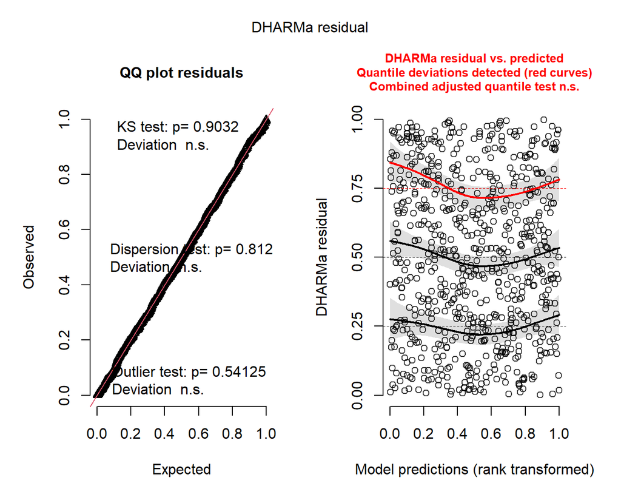

```r
plot(res_mod3)
```

### 5.2. Collinearity

```r
check_collinearity(selected_model)
```

```
# Check for Multicollinearity

Low Correlation

   Term  VIF   VIF 95% CI adj. VIF Tolerance Tolerance 95% CI
    Sex 1.07 [1.02, 1.23]     1.04      0.93     [0.81, 0.98]
 Pclass 1.42 [1.30, 1.57]     1.09      0.71     [0.64, 0.77]
    Age 1.33 [1.23, 1.48]     1.15      0.75     [0.68, 0.81]
```

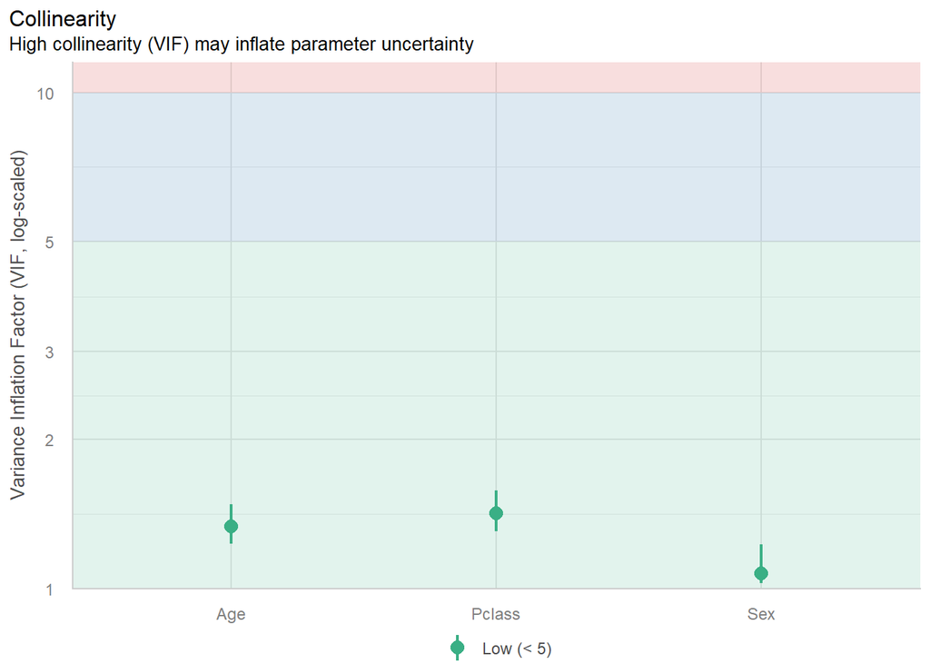

```r
vif_plot <- plot(check_collinearity(selected_model))
vif_plot
```

### 5.3. Complete separation

I check for symptoms of complete or quasi-complete separation, which include:

- Unusually large coefficient estimates or standard errors (SE > 5)
- Convergence warnings from `glmmTMB`
- Fitted probabilities of exactly 0 or 1 for specific predictor combinations

Inspecting `mod3` reveals small, stable standard errors (SE < 0.5) and no convergence warnings, confirming that complete separation is not present.

### 5.4. Influential observations

Because traditional Cook’s distance is not directly implemented for `glmmTMB`, I use `DHARMa::testOutliers()` to test for overly influential observations:

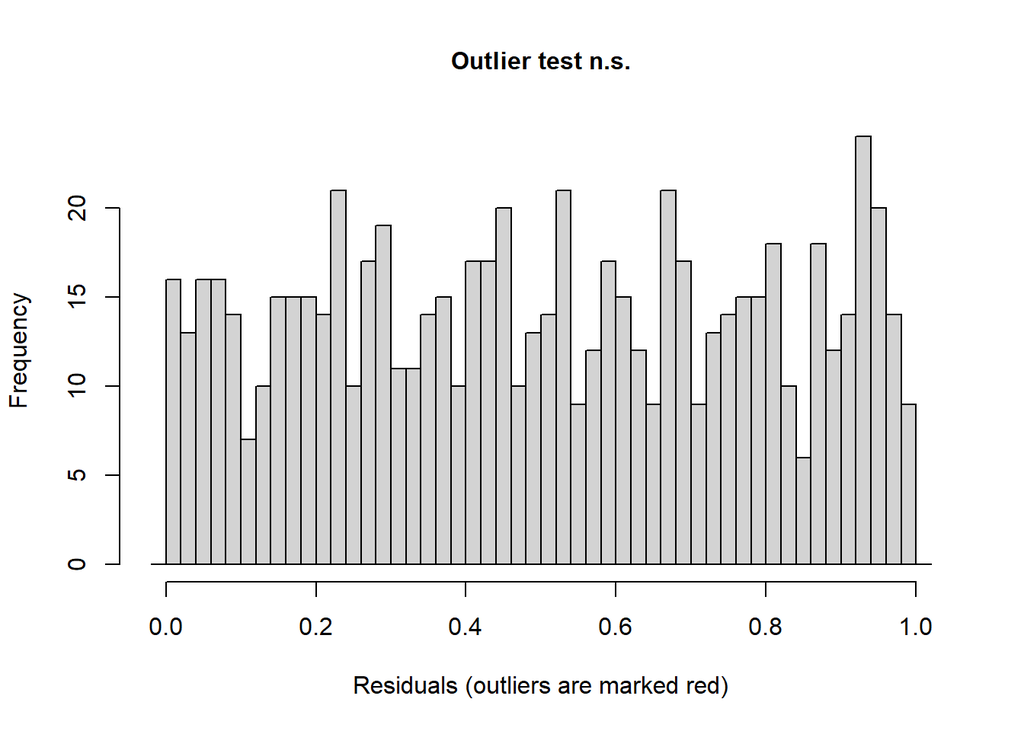

```
    DHARMa outlier test based on exact binomial test with approximate
    expectations

data:  res_mod3
outliers at both margin(s) = 1, observations = 714, p-value = 0.5412
alternative hypothesis: true probability of success is not equal to 0.003992016
95 percent confidence interval:
 3.545849e-05 7.778486e-03
sample estimates:
frequency of outliers (expected: 0.00399201596806387 )
                                            0.00140056
```

```r
testOutliers(res_mod3)
```

### 5.5. Sufficient events per predictor

A standard working guideline for binary logistic regression is to have at least **10 events (and 10 non-events) per estimated coefficient**.

```r
n_event <- sum(titanic$Survived == 1)
n_nonevent <- sum(titanic$Survived == 0)
n_coef <- length(fixef(selected_model)$cond)
epv <- round(min(n_event, n_nonevent) / n_coef, 1)
```

In this dataset, there are **290 survivors (events)** and **424 non-survivors (non-events)** across **5 model coefficients** (including the intercept and two dummy variables for `Pclass`), yielding **58 events per parameter**, far exceeding the minimum threshold of 10 required.

### 5.6. Summary of diagnostic findings

Overall, the diagnostic checks indicate that the assumptions of binary logistic regression are well satisfied for `mod3`.

First, collinearity is negligible as Variance Inflation Factors (VIFs) for `Sex`, `Pclass`, and `Age` are all well below the conservative threshold of 5, indicating that each predictor contributes independent information and also standard errors are not inflated.

Second, there is no evidence of complete separation (all coefficients and standard errors are finite and small) and the sample size provides 58 events per parameter, ensuring stable maximum-likelihood estimation. Third, `DHARMa::testOutliers()` identifies no statistically significant observations (p > .05), and the Q–Q plot of simulated scaled residuals closely tracks the uniform expectation line (non-significant Kolmogorov–Smirnov dispersion and uniformity tests).

While the right-hand `DHARMa` residual-versus-predicted quantile plot shows minor local deviations across predicted probability quantiles which I believe it reflects slight unmodeled interactions between sex and ticket class (for example, survival was particularly high for women in First and Second-Class compared to Third-Class).

These minor deviations do not compromise overall distributional uniformity or parameter stability. Consequently, I can retain and interpret `mod3` with high confidence.

## 6. Select and report preferred model

### 6.1. Justification for my preferred model

Based on statistical fit, information criteria, diagnostics, and substantive theory, **mod3 (`Survived ~ Sex + Pclass + Age`)** is selected as my preferred model.

Statistically, adding `Age` to `Sex` and `Pclass` yielded a highly significant likelihood-ratio test score (χ²(1) = 25.15, p < .001) and had the lowest AIC (657.28) and BIC (680.14) among all four candidate models. Although `mod3` is the most complex model tested, estimating five parameters with n = 714 observations remains parsimonious (58 events per parameter) and introduced zero collinearity or separation.

### 6.2. Extract binary logistic regression coefficients

I use `broom.mixed::tidy()` to extract the unstandardized log-odds coefficients and 95% confidence intervals from `selected_model` (`mod3`), and compute the corresponding odds ratios (`or`) and 95% odds-ratio confidence intervals (`or.conf.low`, `or.conf.high`) for reporting.

```r
coefficient_results <- broom.mixed::tidy(
  selected_model,
  effects = "fixed",
  component = "cond",
  conf.int = TRUE,
  conf.level = 0.95
) |>
  mutate(
    or = exp(estimate),
    or.conf.low = exp(conf.low),
    or.conf.high = exp(conf.high)
  )
```

### 6.3. Formatted binary logistic regression coefficient table

```r
coefficient_results |>
  select(
    term,
    estimate,
    std.error,
    conf.low,
    conf.high,
    p.value
  ) |>
  gt() |>
  cols_label(
    term = "Predictor",
    estimate = "Estimate (Log-Odds)",
    std.error = "SE",
    conf.low = "95% CI Lower",
    conf.high = "95% CI Upper",
    p.value = "p"
  ) |>
  fmt_number(
    columns = c(
      estimate,
      std.error,
      conf.low,
      conf.high
    ),
    decimals = 3
  ) |>
  fmt(
    columns = p.value,
    fns = function(x) {
      ifelse(
        x < .001,
        "< .001",
        sprintf("%.3f", x)
      )
    }
  )
```

| Predictor | Estimate (Log-Odds) | SE | 95% CI Lower | 95% CI Upper | p |
| --- | --- | --- | --- | --- | --- |
| (Intercept) | 3.777 | 0.401 | 2.991 | 4.563 | < .001 |
| Sexmale | −2.523 | 0.207 | −2.929 | −2.116 | < .001 |
| Pclass2 | −1.310 | 0.278 | −1.855 | −0.765 | < .001 |
| Pclass3 | −2.581 | 0.281 | −3.132 | −2.029 | < .001 |
| Age | −0.037 | 0.008 | −0.052 | −0.022 | < .001 |

### 6.4. Overall model performance table for the preferred model

```r
selected_row |>
  select(
    Model,
    AIC,
    BIC,
    logLik,
    deviance,
    df.residual,
    Nested.df,
    Nested.Chisq.stat,
    Nested.p.value
  ) |>
  gt() |>
  cols_label(
    Model = "Model",
    AIC = "AIC",
    BIC = "BIC",
    logLik = "Log-likelihood",
    deviance = "Deviance",
    df.residual = "Residual df",
    Nested.df = "Nested df",
    Nested.Chisq.stat = "Nested χ²",
    Nested.p.value = "Nested p"
  ) |>
  fmt_number(
    columns = c(AIC, BIC, logLik, deviance, Nested.Chisq.stat),
    decimals = 2
  ) |>
  fmt(
    columns = Nested.p.value,
    fns = function(x) {
      ifelse(x < .001, "< .001", sprintf("%.3f", x))
    }
  )
```

| Model | AIC | BIC | Log-likelihood | Deviance | Residual df | Nested df | Nested χ² | Nested p |
| --- | --- | --- | --- | --- | --- | --- | --- | --- |
| mod3: Sex + Pclass + Age | 657.28 | 680.14 | −323.64 | 647.28 | 709 | 1 | 25.15 | < .001 |

## 7. Interpret the results

### 7.1. Inspecting log-odds and odds ratios

```r
fixef(selected_model)
```

```
Conditional model:
(Intercept)      Sexmale      Pclass2      Pclass3          Age
    3.77701     -2.52278     -1.30980     -2.58063     -0.03699
```

I back-transformed the coefficients from the **log-odds** into **odds ratios**, and used the exponentiation function to produce the 95% confidence intervals for the odds ratios:

```r
exp(fixef(selected_model)$cond)
```

```
(Intercept)     Sexmale     Pclass2     Pclass3         Age
43.68537504  0.08023611  0.26987411  0.07572659  0.96369034
```

```r
or_ci <- exp(confint(selected_model, parm = "beta_"))
or_ci
```

```
                  2.5 %     97.5 %    Estimate
(Intercept) 19.90247237 95.8881870 43.68537504
Sexmale      0.05343656  0.1204762  0.08023611
Pclass2      0.15648543  0.4654238  0.26987411
Pclass3      0.04362034  0.1314643  0.07572659
Age          0.94933776  0.9782599  0.96369034
```

### 7.2. Interpreting each predictor on the log-odds and odds-ratio scales

Every predictor in `mod3` is interpreted while holding the remaining predictors in the model constant:

- **Sex (`male` vs. reference group `female`):** Holding ticket class (`Pclass`) and `Age` constant, being male is associated with a decrease in the **log-odds** of surviving the Titanic crash of 2.52 (b = -2.52, SE = 0.21, p < .001). On the **odds-ratio** scale, holding ticket class and age constant, male passengers had 0.08 times the odds of surviving compared to female passengers (95% CI [0.05, 0.12]), meaning man’s odds of survival were 92% lower than woman’s.
- **Second-Class passenger (`Pclass2` vs. reference group `Pclass1` [First Class]):** Holding passenger `Sex` and `Age` constant, traveling in Second-Class rather than First-Class is associated with a decrease in the **log-odds** of survival of 1.31 (b = -1.31, SE = 0.28, p < .001). Transformed into an **odds ratio**, holding sex and age constant, Second-Class passengers had 0.27 times the odds of surviving compared to First-Class passengers (95% CI [0.16, 0.47]), representing a 73% reduction in survival odds.
- **Third-Class passengers (`Pclass3` vs. reference group `Pclass1` [First Class]):** Holding passenger `Sex` and `Age` constant, traveling in Third-Class rather than First-Class is associated with a decrease in the **log-odds** of survival of 2.58 (b = -2.58, SE = 0.28, p < .001). On the **odds-ratio** scale, holding sex and age constant, Third-Class passengers had 0.08 times the odds of surviving compared to First-Class passengers (95% CI [0.04, 0.13]), corresponding to a 92.4% reduction in the odds of survival.
- **Age (`Age`):** Holding passenger `Sex` and ticket class (`Pclass`) constant, each one-year increase in age is associated with a decrease in the **log-odds** of survival of 0.04 (b = -0.04, SE = 0.01, p < .001). As an **odds ratio**, holding sex and ticket class constant, a one-year increase in age is associated with 0.96 times the odds of surviving (95% CI [0.95, 0.98]), or a 3.6% decrease in the odds of survival per additional year of age.

### 7.3. Overarching summary paragraph of results

To investigate the demographic and socioeconomic factors associated with surviving the sinking of the Titanic (n = 714), I estimated and compared a series of four nested binary logistic regression models using `glmmTMB`. Model comparisons using likelihood-ratio tests, AIC, and BIC consistently supported the full three-predictor model (`mod3: Survived ~ Sex + Pclass + Age`), which significantly improved model fit over simpler specifications (Δχ²(1) = 25.15, p < .001; AIC = 657.28, BIC = 680.14). In the preferred model, all three predictors were statistically significant and in the predicted directions.

Controlling for ticket class and age, male passengers had substantially lower odds of surviving than female passengers, OR = 0.08, 95% CI [0.05, 0.12], p < .001.

Socioeconomic status (measured via ticket class) was also strongly associated with survival: holding sex and age constant, passengers in Second-Class (OR = 0.27, 95% CI [0.16, 0.47], p < .001) and Third-Class (OR = 0.08, 95% CI [0.04, 0.13], p < .001) had markedly lower odds of surviving compared to First-Class passengers.

Finally, holding sex and ticket class constant, older age was associated with lower odds of surviving, OR = 0.96 per year, 95% CI [0.95, 0.98], p < .001.

### 7.4. Visualizing results as predicted probabilities

I can visualize the associations between my predictors and `Survived` using **predicted probabilities** calculated with `ggeffects::ggpredict()` and plotted with `ggplot2`.

#### Predicted probability of survival across Age

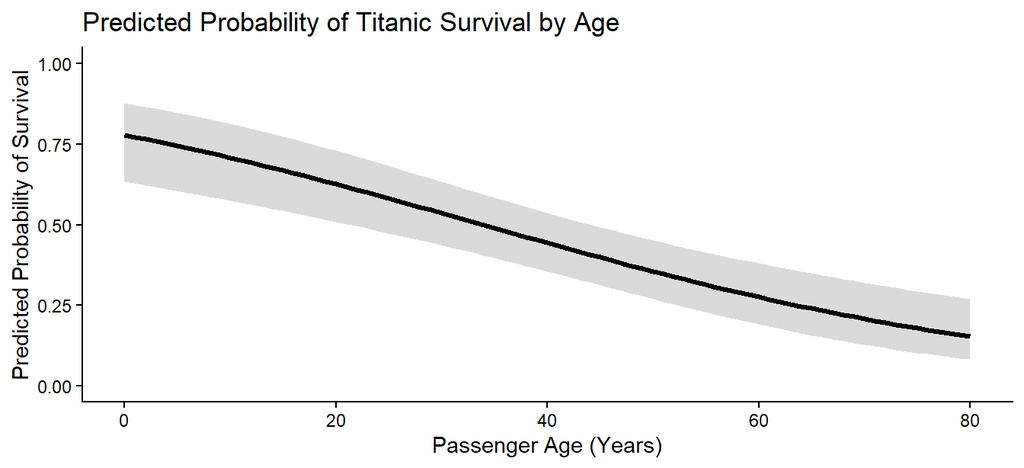

```r
pred_age <- ggpredict(selected_model, terms = "Age [0:80 by=1]")

ggplot(pred_age, aes(x = x, y = predicted)) +
  geom_ribbon(aes(ymin = conf.low, ymax = conf.high), alpha = 0.18) +
  geom_line(linewidth = 1.2) +
  scale_y_continuous(limits = c(0, 1)) +
  labs(
    x = "Passenger Age (Years)",
    y = "Predicted Probability of Survival",
    title = "Predicted Probability of Titanic Survival by Age"
  ) +
  theme_classic()
```

#### Predicted probability of survival across Ticket Class

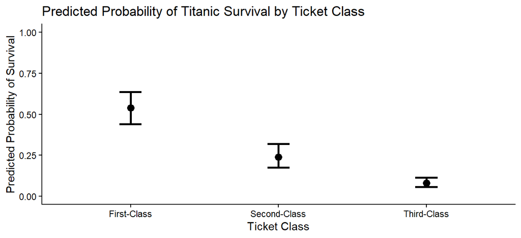

```r
pred_pclass <- ggpredict(selected_model, terms = "Pclass")

ggplot(pred_pclass, aes(x = x, y = predicted)) +
  geom_point(size = 3) +
  geom_errorbar(aes(ymin = conf.low, ymax = conf.high), width = 0.15, linewidth = 0.9) +
  scale_x_discrete(labels = c("1" = "First-Class", "2" = "Second-Class", "3" = "Third-Class")) +
  scale_y_continuous(limits = c(0, 1)) +
  labs(
    x = "Ticket Class",
    y = "Predicted Probability of Survival",
    title = "Predicted Probability of Titanic Survival by Ticket Class"
  ) +
  theme_classic()
```

## 8. Discuss findings and limitations

### 8.1 Substantive conclusions on relative predictor importance

The results of my analysis provide clear evidence that survival during the sinking of the Titanic was associated with sex, ticket class (SES), and age:

- **Passenger Sex:** Sex was the single strongest predictor of survival, accounting for the largest reduction in model deviance (Δχ² = 213.82). Holding ticket class and age constant, man had only 0.08 times the odds of surviving compared to woman, reflecting strict following of the “women and children first” principle.
- **Ticket Class (SES):** Ticket class was the second most influential factor (Δχ² = 78.27). Even when comparing passengers of the same sex and age, Second-Class passengers had 73% lower odds of survival and Third-Class passengers had 92.4% lower odds of survival than First-Class passengers. Physical proximity to the boat deck and social privilege gave wealthy passengers a decisive survival advantage.
- **Age:** Age provided a smaller but still statistically significant incremental contribution (Δχ² = 25.15). Each additional year of age reduced the odds of survival by 3.6% holding sex and class constant, consistent with children receiving priority access to lifeboats and older adults facing greater physical challenges during the evacuation.

### 8.2 Limitations

Several methodological and substantive limitations are presented in my results:

- **Missing data and complete-case restriction:** Filtering the `titanic_train` dataset via `drop_na()` excluded 177 passengers who were missing `Age` records (reducing the sample from 891 to 714 passengers). Because Third-Class passengers were disproportionately more likely to have missing age records, complete-case analysis may introduce selection bias because the missingness wasn’t random.
- **Additive main-effects specification:** My preferred model (`mod3`) assumes additive effects on the logit scale (`Survived ~ Sex + Pclass + Age`). Historical records suggest that the benefit of being female was substantially weaker in Third-Class than in First or Second-Class. Therefore, I need further analyses to test the `Sex * Pclass` interaction effect of moderation.
- **Unmeasured confounders:** Other important passenger characteristics such as cabin location, number of siblings/spouses or parents/children aboard, and language barriers were not included in my models and may partially confound the observed associations of ticket class and age with survival.